# Assignment 3: Model comparison

Bela Szlovicsak

In this lab assignment you are going to work with (simulated) data related to perioperative pain and its psychological and hormonal predictors. In the assignment you will assess the added benefit of including some psychological and hormonal predictors to the already established demographic predictors of pain.

In this assignment you will set up a hierarchical regression model to predict postoperative pain after wisdom tooth surgery.

# Research problem

The amount of pain experienced around and after surgeries are highly variable between and within individuals. In order to improve surgical pain management regimens we need to understand what influences pain around surgical procedures and predict the amount of pain an individual will experience.

Your first study in this area is related to assessing the influence of trait and state psychological measures on pain, and to see whether taking into account these variables can improve our understanding of postoperative pain.

# Procedures and measures

Use the data file called ‘assignment_3_dataset’, from the ‘data/’ folder.

You have collected data from 160 adults who were scheduled to undergo surgical extraction of the third mandibular molar (wisdom tooth surgery). Patients filled out a form in the waiting room before their surgery. The form contained questions about their sex, age, and weight, and psychological questionnaires assessing anxiety, pain catastrophizing, and mindfulness (see descriptions below). You also got blood samples and saliva samples from participants in the waiting room 5 minutes before their operations to determine the serum (a component of the blood) and salivary cortisol levels of participants. Participants were contacted 5 hours after the surgery to see how much pain they were experiencing. The **level of pain** at that moment was recorded using a numerical rating scale using a **scale of 0 to 10**, where 0 means “no pain” and 10 means “worst pain I can imagine”.

**The State Trait Anxiety Inventory:** T measures trait anxiety on a scale of 20 to 80, higher scores mean higher anxiety. Anxiety has been found in many studies to positively correlate with the level of pain experienced. This is **variable STAI_trait** in the dataset.

**The Pain Catastrophizing Scale** measures the extent of pain catastrophizing, which is characterized by a tendency to magnify the threat value of a pain stimulus and to feel helpless in the presence of pain, as well as by a relative inability to prevent or inhibit pain-related thoughts in anticipation of, during, or following a painful event. The total score on this scale ranges from 0 to 52, higher scores mean higher catastrophizing. Pain catastrophizing is one of the well-established predictors of clinical pain. This is **variable pain_cat** in the dataset.

**The Mindful Attention Awareness Scale (MAAS)** measures dispositional mindfulness, which may be described as a tendency to turn attention to present-moment experiences in an open, non-judgmental way. The MAAS total score ranges from 1 to 6 (an average of the item scores), with higher scores representing higher dispositional mindfulness. Trait mindfulness has been theorized to serve as a protective factor against pain, as the individual would be more objective about their pain experience and tend to associate less discomfort, despair, and hopelessness to the pain-related sensations. This is **variable mindfulness** in the dataset.

**Cortisol** is a stress hormone associated with acute and chronic stress. Cortisol levels are thought to be positively associated with pain experience. Cortisol can be **measured from both blood and the saliva**, although, serum cortisol is often regarded in medical research as more reliably related to stress (serum is a component of the blood plasma). These are **variables cortisol_serum**, and **cortisol_saliva** in the dataset.

# Research question

Previous studies and meta-analyses showed that age and sex are often predictors of pain (age is negatively associated with pain, while sex is a predictor more dependent on the type of the procedure). You would like to determine the extent to which taking into account psychological and hormonal variables aside from the already used demographic variables would improve our understanding of postoperative pain.

To answer this research question you will **need to compare two models** (with a hierarchical regression). The **simpler model** should contain **age and sex as predictors of pain**, while the **more complex model** should contain the **predictors: age, sex, STAI, pain catastrophizing, mindfulness, and cortisol measures**. Notice that the predictors used in the simpler model are a subset of the predictors used in more complex model. **You will have to do model comparison to assess whether substantial new information was gained about pain in the more complex model compared to the simpler model.**

# What to report

As usual, before you can interpret your model, you will need to run data and model diagnostics. First, check the variables included in the more complex model (age, sex, STAI, pain catastrophizing, mindfulness, and cortisol measures as predictors, and pain as an outcome) for **coding errors**, and the model itself for **influential outliers** (for example using Cook’s distance). Furthermore, check the final model to see if the **assumptions of linear regression hold true**, that is, **normality** (of the residuals), **linearity** (of the relationship), **homogeneity of variance** (also called homoscedasticity) and that there is no excess **multicollinearity** (“uncorrelated predictors” in Navarro’s words). If you find anything amiss during these checks, make the appropriate decision or correction and report your findings and actions in your report.

**Note:** If you do any changes, such as exclude cases, or exclude predictors from the model, you will have to re-run the above checks for your final data and model.

Report the results of the simpler model and the more complex model. For both models you should report the model test statistics (adj.R2, F, df, and p value). Also, report the statistics describing the coefficients of the predictors in a table format (unstandardized regression coefficients and 95% confidence intervals, standardized regression coefficients (B and Beta values), and p values).

Write up the regression equation of the more complex model in the form of 𝑌 = 𝑏0 + 𝑏1 ∗ X1 + 𝑏2 ∗ X2 +…+ bn * Xn, in which you use the actual regression coefficients of your models. (b0 stands for the intercept and b1, b2 … bn stand for the model coefficients for each of the predictors, and X1, X2, … Xn denote the predictors).

Compare the two models in terms of how much variance they explain of pain’s variability in the sample. Report Akaike information criterion (AIC) for both models and the F test statistic and p value of the likelihood ratio test comparing the two models.

# What to discuss

In your discussion of the findings, briefly interpret the results of the above analyses, and indicate whether you think that anything was gained by including the psychological and hormone measures in the model.

# Solution

## Read the data

Read the dataset used in this assignment. Pay attention to the extension of the datafile.

```r
pain_data <- read_xlsx("~/R_Projects/r_data_analysis-22_23_fall/data/assignment_3_dataset.xlsx")
```

## Data and model diagnostics

### Data diagnostics

#### Descriptives of the variables

Run an exploratory data analysis (EDA) to investigate the dataset.

```r
str(pain_data)
```

```
## tibble [160 × 12] (S3: tbl_df/tbl/data.frame)
##  $ ID              : chr [1:160] "ID_1" "ID_2" "ID_3" "ID_4" ...
##  $ pain            : num [1:160] 5 4 5 7 4 6 4 5 4 5 ...
##  $ sex             : chr [1:160] "female" "female" "female" "female" ...
##  $ age             : num [1:160] 38 36 51 39 48 45 45 35 39 33 ...
##  $ STAI_trait      : num [1:160] 39 46 49 48 36 37 34 39 31 38 ...
##  $ pain_cat        : num [1:160] 25 31 32 41 26 28 22 32 27 36 ...
##  $ cortisol_serum  : num [1:160] 4.67 6.01 5.18 6.65 2.95 4.32 5.32 5.26 3.36 5.96 ...
##  $ cortisol_saliva : num [1:160] 4.78 6.71 4.75 6.68 3.2 4.36 5.19 5.53 3.3 5.78 ...
##  $ mindfulness     : num [1:160] 3.83 2.82 3.93 1.9 4.39 3.01 4.97 2.95 3.43 1.85 ...
##  $ weight          : num [1:160] 62.1 97.1 79 78.5 76.9 ...
##  $ IQ              : num [1:160] 99 71 97 97 129 115 74 98 93 76 ...
##  $ household_income: num [1:160] 52505 64993 68598 47822 100580 ...
```

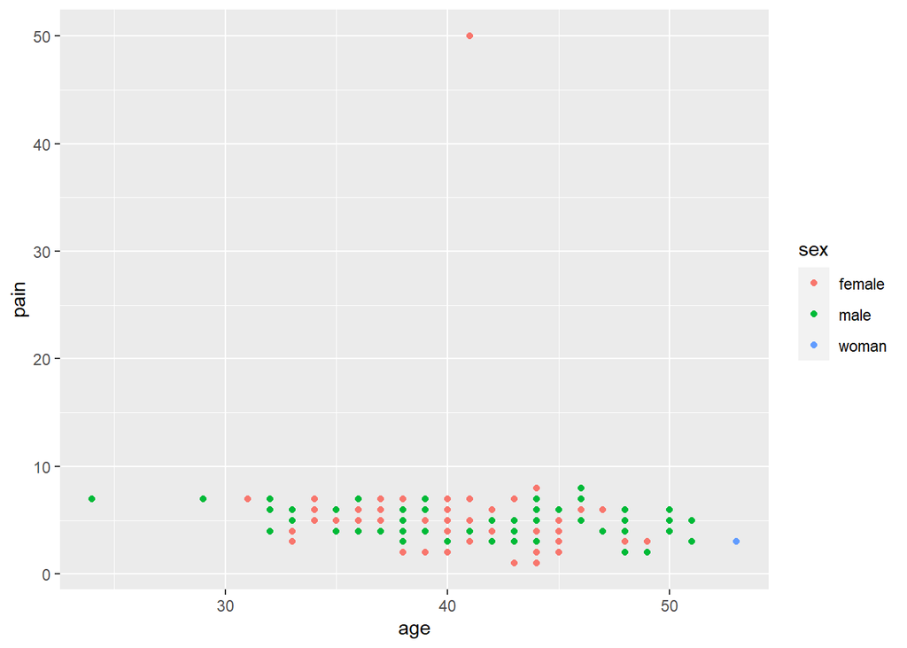

```r
#Exploring outliers with plots and a summary

pain_data %>%
  ggplot(aes(
    age,
    pain,
    color = sex
  )) +
  geom_point()
```

```r
#There are coding errors that need to be removed: pain above 10, and unifying woman and female


summary(pain_data)
```

```
##       ID                 pain            sex                 age
##  Length:160         Min.   : 1.000   Length:160         Min.   :24.00
##  Class :character   1st Qu.: 4.000   Class :character   1st Qu.:38.00
##  Mode  :character   Median : 5.000   Mode  :character   Median :41.00
##                     Mean   : 5.194                      Mean   :40.74
##                     3rd Qu.: 6.000                      3rd Qu.:44.00
##                     Max.   :50.000                      Max.   :53.00
##    STAI_trait       pain_cat     cortisol_serum  cortisol_saliva
##  Min.   :26.00   Min.   :14.00   Min.   :2.700   Min.   :2.530
##  1st Qu.:37.00   1st Qu.:27.00   1st Qu.:4.268   1st Qu.:4.120
##  Median :40.00   Median :30.00   Median :4.995   Median :5.035
##  Mean   :40.09   Mean   :29.88   Mean   :4.941   Mean   :4.952
##  3rd Qu.:43.00   3rd Qu.:32.25   3rd Qu.:5.633   3rd Qu.:5.753
##  Max.   :52.00   Max.   :42.00   Max.   :7.110   Max.   :7.190
##   mindfulness        weight            IQ         household_income
##  Min.   :1.000   Min.   :33.80   Min.   : 52.00   Min.   :  5548
##  1st Qu.:2.595   1st Qu.:62.15   1st Qu.: 91.75   1st Qu.: 53489
##  Median :3.115   Median :68.77   Median :101.00   Median : 72149
##  Mean   :3.204   Mean   :68.57   Mean   :100.74   Mean   : 70426
##  3rd Qu.:3.830   3rd Qu.:74.65   3rd Qu.:109.00   3rd Qu.: 87734
##  Max.   :6.220   Max.   :97.13   Max.   :144.00   Max.   :139268
```

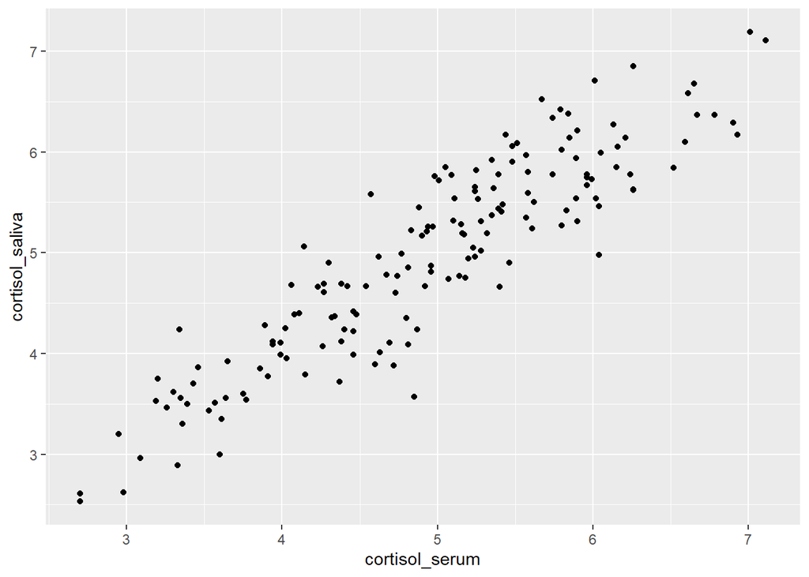

```r
#At least one of the mindfulness scores is above 6, this also needs to be dealt with

ggplot(pain_data,
       aes(
         cortisol_serum,
         cortisol_saliva
       )) +
  geom_point()
```

```r
#The two levels don't differ significantly which is to be expected, but because of this probably on of these variables will be dropped to evade multicollinearity
```

#### Correct coding errors

If you find values in the dataset during the EDA, that are not correct based on the provided descriptions of the variables of the dataset please correct them here.

```r
pain_data2 <- pain_data %>%
  filter(pain <= 10) %>%
  mutate(sex = str_replace(sex, "woman", "female"),
         mindfulness = if_else(mindfulness > 6, 6, mindfulness))

#Now all values are within the given bounds
summary(pain_data2)
```

```
##       ID                 pain           sex                 age
##  Length:159         Min.   :1.000   Length:159         Min.   :24.00
##  Class :character   1st Qu.:4.000   Class :character   1st Qu.:38.00
##  Mode  :character   Median :5.000   Mode  :character   Median :41.00
##                     Mean   :4.912                      Mean   :40.74
##                     3rd Qu.:6.000                      3rd Qu.:44.00
##                     Max.   :8.000                      Max.   :53.00
##    STAI_trait       pain_cat     cortisol_serum  cortisol_saliva
##  Min.   :26.00   Min.   :14.00   Min.   :2.700   Min.   :2.530
##  1st Qu.:37.00   1st Qu.:27.00   1st Qu.:4.265   1st Qu.:4.120
##  Median :40.00   Median :30.00   Median :4.980   Median :5.020
##  Mean   :40.07   Mean   :29.87   Mean   :4.936   Mean   :4.945
##  3rd Qu.:43.00   3rd Qu.:32.50   3rd Qu.:5.615   3rd Qu.:5.740
##  Max.   :52.00   Max.   :42.00   Max.   :7.110   Max.   :7.190
##   mindfulness        weight            IQ        household_income
##  Min.   :1.000   Min.   :33.80   Min.   : 52.0   Min.   :  5548
##  1st Qu.:2.590   1st Qu.:62.15   1st Qu.: 91.5   1st Qu.: 53364
##  Median :3.110   Median :68.75   Median :101.0   Median : 72111
##  Mean   :3.203   Mean   :68.54   Mean   :100.6   Mean   : 70402
##  3rd Qu.:3.830   3rd Qu.:74.72   3rd Qu.:108.5   3rd Qu.: 87887
##  Max.   :6.000   Max.   :97.13   Max.   :144.0   Max.   :139268
```

```r
unique(pain_data2$sex)
```

```
## [1] "female" "male"
```

```r
#Checking the base model for outliers
model1 <- lm(pain ~ sex + age, data = pain_data2)
print(model1)
```

```
##
## Call:
## lm(formula = pain ~ sex + age, data = pain_data2)
##
## Coefficients:
## (Intercept)      sexmale          age
##     8.49145      0.10287     -0.08906
```

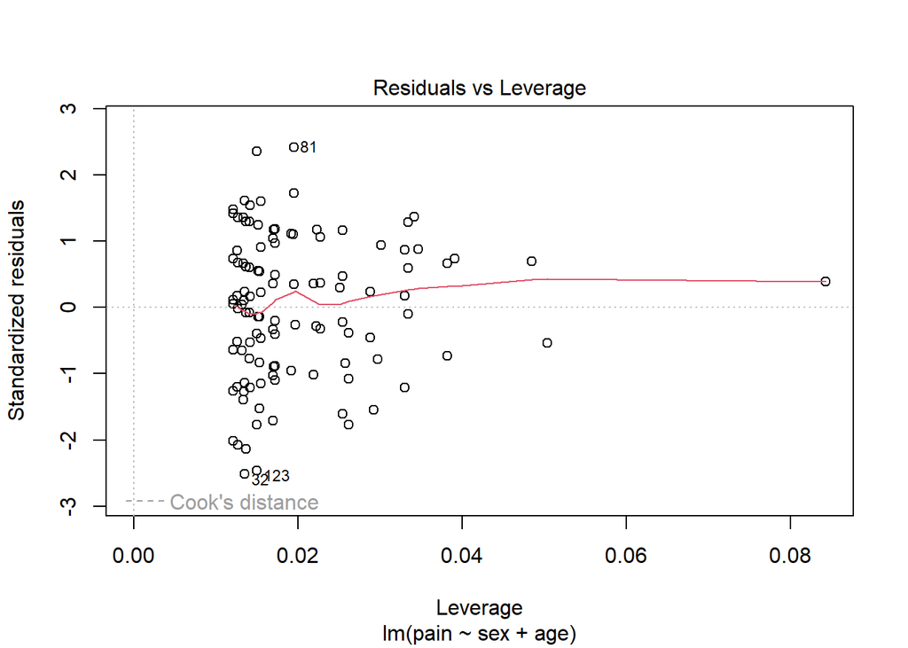

```r
plot(model1, 5)
```

```r
#There seems to be no outliers with a Cook's distance much larger than others.
```

### Model diagnostics

#### Build the more complex model

In order to test the more complex model for outliers and to test the assumptions first build the model.

```r
model2 <- lm(pain ~ sex + age + STAI_trait + pain_cat + cortisol_serum + cortisol_saliva + mindfulness, data = pain_data2)


summary(model2)
```

```
##
## Call:
## lm(formula = pain ~ sex + age + STAI_trait + pain_cat + cortisol_serum +
##     cortisol_saliva + mindfulness, data = pain_data2)
##
## Residuals:
##     Min      1Q  Median      3Q     Max
## -3.2327 -0.7776 -0.0420  0.7737  2.9571
##
## Coefficients:
##                 Estimate Std. Error t value Pr(>|t|)
## (Intercept)      1.33791    1.72512   0.776  0.43923
## sexmale          0.31654    0.21062   1.503  0.13496
## age             -0.02398    0.02415  -0.993  0.32223
## STAI_trait      -0.02539    0.02787  -0.911  0.36382
## pain_cat         0.09509    0.02877   3.305  0.00119 **
## cortisol_serum   0.16651    0.24532   0.679  0.49833
## cortisol_saliva  0.43770    0.25213   1.736  0.08460 .
## mindfulness     -0.12801    0.12509  -1.023  0.30779
## ---
## Signif. codes:  0 '***' 0.001 '**' 0.01 '*' 0.05 '.' 0.1 ' ' 1
##
## Residual standard error: 1.242 on 151 degrees of freedom
## Multiple R-squared:  0.3647, Adjusted R-squared:  0.3352
## F-statistic: 12.38 on 7 and 151 DF,  p-value: 1.793e-12
```

```r
tidy(model2)
```

```
## # A tibble: 8 × 5
##   term            estimate std.error statistic p.value
##   <chr>              <dbl>     <dbl>     <dbl>   <dbl>
## 1 (Intercept)       1.34      1.73       0.776 0.439
## 2 sexmale           0.317     0.211      1.50  0.135
## 3 age              -0.0240    0.0241    -0.993 0.322
## 4 STAI_trait       -0.0254    0.0279    -0.911 0.364
## 5 pain_cat          0.0951    0.0288     3.31  0.00119
## 6 cortisol_serum    0.167     0.245      0.679 0.498
## 7 cortisol_saliva   0.438     0.252      1.74  0.0846
## 8 mindfulness      -0.128     0.125     -1.02  0.308
```

#### Checking for influential outliers

Check for outlier values in the model.

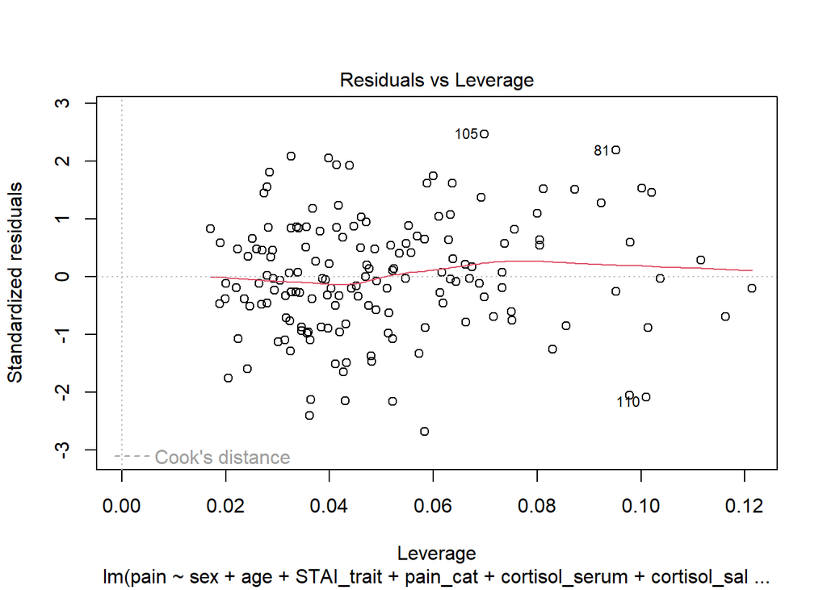

```r
plot(model2, 5)
```

```r
#Even the highest points are within reason, there are no too influential outliers
```

#### Checking assumptions

Check the normality assumption.

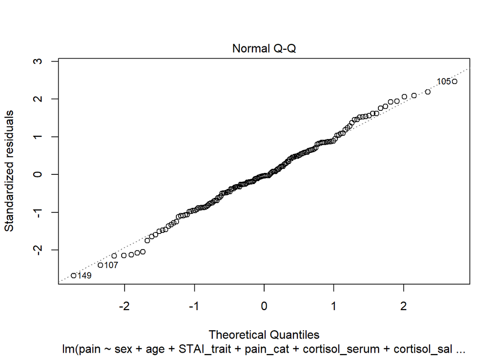

```r
plot(model2, 2)
```

```r
#The points fall along the diagonal, normality can be assumed
```

Check the linearity assumption.

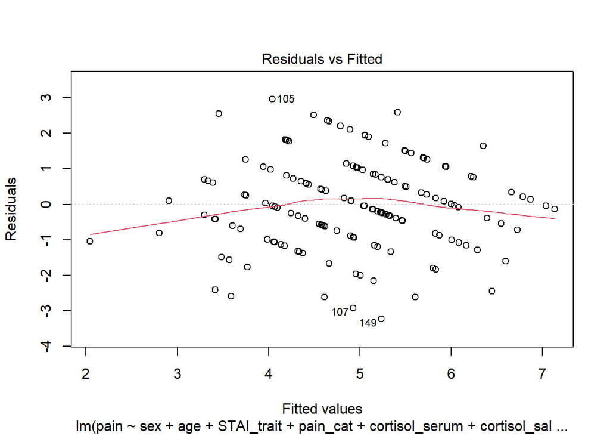

```r
plot(model2,1)
```

```r
#Linearity does not seem to hold, a transformation of some of the explanatory variables is needed
```

Check the homoscedasticty assumption (homogeneity of variance).

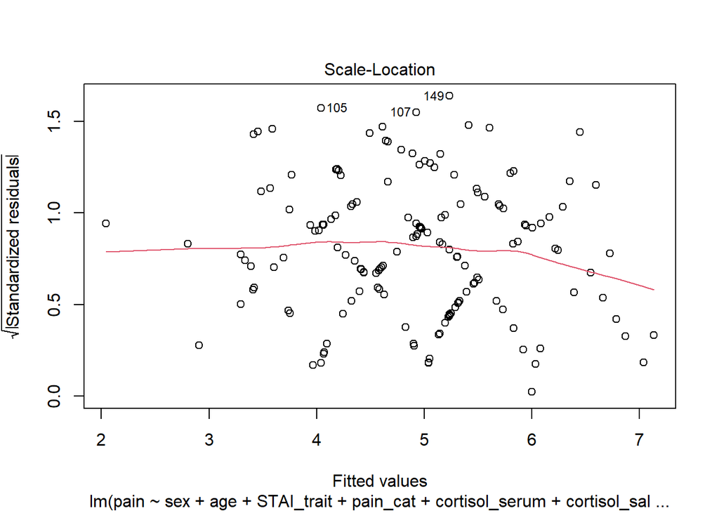

```r
plot(model2, 3)
```

```r
#homoscedasticty does not seem to hold either, the transformation of the response variable might help with this
```

Check the multicollinearity assumption.

(VIF above 5), or a VIF threshold of 3 is recommended in this paper: http://onlinelibrary.wiley.com/doi/10.1111/j.2041-210X.2009.00001.x/full

Some info about VIF: https://statisticalhorizons.com/multicollinearity http://blog.minitab.com/blog/understanding-statistics/handling-multicollinearity-in-regression-analysis

```r
vif(model2)
```

```
##             sex             age      STAI_trait        pain_cat  cortisol_serum
##        1.140507        1.528085        2.115685        1.946760        6.065225
## cortisol_saliva     mindfulness
##        6.624112        1.526027
```

```r
#As expected the cortisol variables are correlated, cortisol_saliva will be removed first than vif checked again
```

### Making decision based on model diagnostics

If based on the assumption tests you decide to drop a predictor variable you should do that here. Create your updated model.

```r
model3 <- lm(pain ~ sex
             + age + STAI_trait + pain_cat + cortisol_serum
             + mindfulness,
             data = pain_data2)
```

#### Checking outliers of the updated model

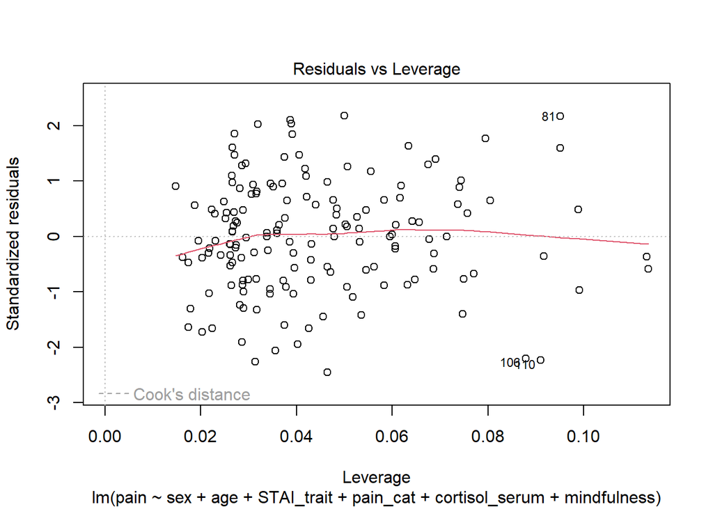

```r
plot(model3, 5)
```

```r
#There are no outliers
```

#### Checking assumptions of the updated model

Normality assumption

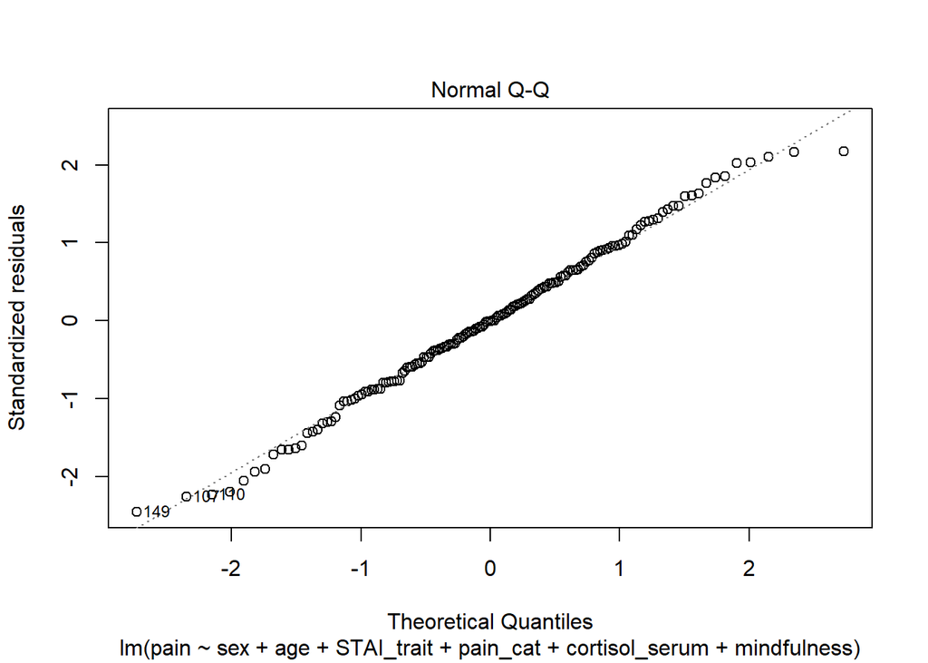

```r
plot(model3, 2)
```

```r
#The residuals are reasonable normal
```

Linearity assumption

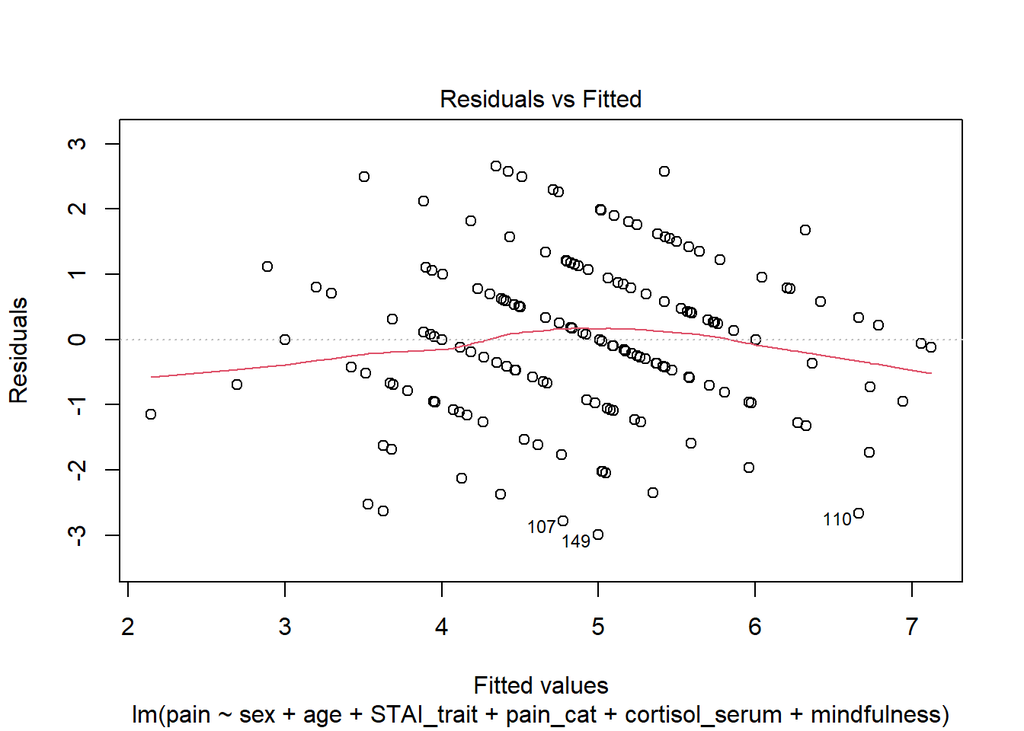

```r
plot(model3, 1)
```

```r
#linearity is not perfect, but transformations didn't really help either. It's still better than model2
```

[output not shown]

[output not shown]

Homoscedasticty assumption (homogeneity of variance)

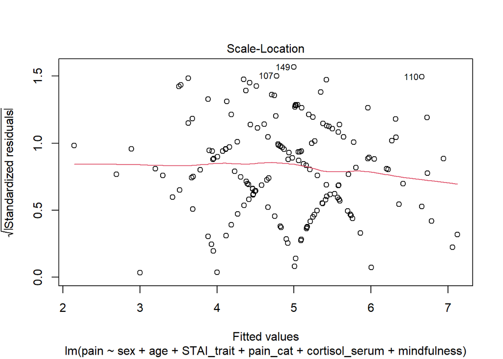

```r
plot(model3, 3)
```

```r
#it's the same case as it was with linearity
```

Multicollinearity assumption

```r
vif(model3)
```

```
##            sex            age     STAI_trait       pain_cat cortisol_serum
##       1.140201       1.403102       1.932533       1.863522       1.524561
##    mindfulness
##       1.516941
```

```r
#Removing cortisol_saliva solved the issue of multicollineartity
```

## Model comparison

Create the simple model and get the results of the model that needs to be reported based on the What to report section.

```r
#Model1 was already created

glance(model1)
```

```
## # A tibble: 1 × 12
##   r.squ…¹ adj.r…² sigma stati…³ p.value    df logLik   AIC   BIC devia…⁴ df.re…⁵
##     <dbl>   <dbl> <dbl>   <dbl>   <dbl> <dbl>  <dbl> <dbl> <dbl>   <dbl>   <int>
## 1  0.0878  0.0761  1.46    7.51 7.68e-4     2  -285.  578.  590.    335.     156
## # … with 1 more variable: nobs <int>, and abbreviated variable names
## #   ¹r.squared, ²adj.r.squared, ³statistic, ⁴deviance, ⁵df.residual
```

```r
tidy(model1, conf.int = TRUE, conf.level = 0.95)
```

```
## # A tibble: 3 × 7
##   term        estimate std.error statistic  p.value conf.low conf.high
##   <chr>          <dbl>     <dbl>     <dbl>    <dbl>    <dbl>     <dbl>
## 1 (Intercept)   8.49      0.948      8.95  9.64e-16    6.62    10.4
## 2 sexmale       0.103     0.233      0.442 6.59e- 1   -0.357    0.562
## 3 age          -0.0891    0.0230    -3.86  1.63e- 4   -0.135   -0.0435
```

Create the more complex model based on the results of the model diagnostics. Also, get the results that needs to be reported based on the What to report section.

```r
#Using model3

glance(model3)
```

```
## # A tibble: 1 × 12
##   r.squared adj.r.squa…¹ sigma stati…²  p.value    df logLik   AIC   BIC devia…³
##       <dbl>        <dbl> <dbl>   <dbl>    <dbl> <dbl>  <dbl> <dbl> <dbl>   <dbl>
## 1     0.352        0.326  1.25    13.8 1.87e-12     6  -258.  531.  556.    238.
## # … with 2 more variables: df.residual <int>, nobs <int>, and abbreviated
## #   variable names ¹adj.r.squared, ²statistic, ³deviance
```

```r
tidy(model3, conf.int = TRUE, conf.level = 0.95)
```

```
## # A tibble: 7 × 7
##   term           estimate std.error statistic   p.value conf.low conf.high
##   <chr>             <dbl>     <dbl>     <dbl>     <dbl>    <dbl>     <dbl>
## 1 (Intercept)      1.97      1.70       1.16  0.249      -1.39      5.32
## 2 sexmale          0.311     0.212      1.46  0.145      -0.108     0.729
## 3 age             -0.0360    0.0233    -1.54  0.125      -0.0820    0.0100
## 4 STAI_trait      -0.0112    0.0268    -0.416 0.678      -0.0641    0.0418
## 5 pain_cat         0.0848    0.0283     2.99  0.00324     0.0288    0.141
## 6 cortisol_serum   0.535     0.124      4.32  0.0000279   0.290     0.780
## 7 mindfulness     -0.145     0.126     -1.15  0.251      -0.393     0.103
```

Compare the two models.

```r
anova(model1, model3)
```

```
## Analysis of Variance Table
##
## Model 1: pain ~ sex + age
## Model 2: pain ~ sex + age + STAI_trait + pain_cat + cortisol_serum + mindfulness
##   Res.Df    RSS Df Sum of Sq      F    Pr(>F)
## 1    156 334.55
## 2    152 237.66  4    96.888 15.491 1.191e-10 ***
## ---
## Signif. codes:  0 '***' 0.001 '**' 0.01 '*' 0.05 '.' 0.1 ' ' 1
```

Using Anova to compare the two models we can see that there is a significant difference between them. It seems that the more complex model can explain more variance.

From all the variables only cortisol_saliva was removed, but the data is still not entirly linear no heteroscadistic, which is not helped by using transformations on the variables either. Using a more complex, mixed effect model might help.